# Titanic - Machine Learning from Disaster

Kaggle Competition

# Project Motivation

I want to practice using machine learning algorithms to improve my model predictions. Here are some usefule resources.

- Using R for machine learning https://tensorflow.rstudio.com/
- Kaggle Data Competition
  - A well structured machine learning problem with data https://www.kaggle.com/competitions/titanic/overview
- Tidymodels collection of packages
  - https://www.tidymodels.org/learn/
- Keras Cheat Sheet
  - https://rstudio.github.io/cheatsheets/html/keras.html

# Load Libraries and Import Data

```r
# load libraries
library(tensorflow)   # machine leaning
library(keras)        # machine leaning
library(tidyverse)    # data import/cleaning/inspection
library(tidymodels)   # model building
library(here)         # relative file paths
```

```r
library(naniar)       # missing data plot
library(DT)           # datatables for interactive tables
```

```r
# import data
training_data <- read_csv(file = here("data",
                                      "kaggle",
                                      "titanic",
                                      "train.csv"))
```

## Data Cleaning

### Inspect Variables

#### `PassengerId`

There are 891 unique passenger IDs. Given the arbitrary nature of the IDs, they will be omitted from the model.

#### `Survived`

Survival of the passenger where 0 = No and 1 = Yes.

```r
# get counts of survival
training_data %>%
  count(Survived) %>%
  datatable(rownames = FALSE,
            options = list(dom = "tp"))
```

| Survived | n |
| --- | --- |
| 0 | 549 |
| 1 | 342 |

#### `Pclass`

Ticket class 1 = 1st, 2 = 2nd, 3 = 3rd

```r
# get counts of passenger class
training_data %>%
  count(Pclass) %>%
  datatable(rownames = FALSE,
            options = list(dom = "tp"))
```

| Pclass | n |
| --- | --- |
| 1 | 216 |
| 2 | 184 |
| 3 | 491 |

#### `Name`

There are 891 unique passenger names. Given the arbitrary nature of the names, they will be omitted from the model. However, we might be able to improve the accuracy of the model if we could cluster/group the data based upon familial connections (i.e., children with parents on board when the parents survived)

#### `Sex`

```r
# get counts of "Sex"
training_data %>%
  count(Sex) %>%
  datatable(rownames = FALSE,
            options = list(dom = "tp"))
```

| Sex | n |
| --- | --- |
| female | 314 |
| male | 577 |

#### `Age`

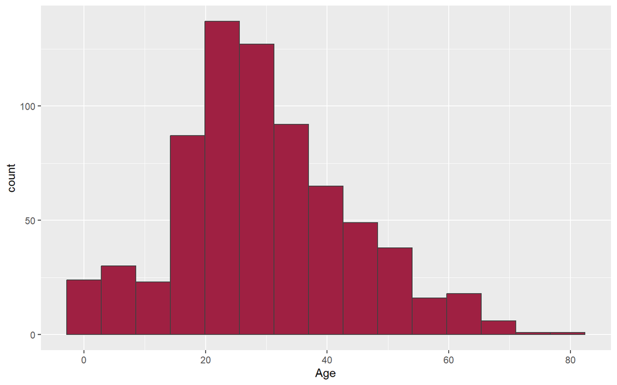

```r
# create histogram of age
training_data %>%
  ggplot(aes(x = Age)) +
  geom_histogram(bins = 15, fill = "#9F2042", color = "#404040")
```

#### `SibSp`

Number of siblings / spouses aboard the Titanic

```r
# get count of sibling/spouses onboard
training_data %>%
  count(SibSp) %>%
  datatable(rownames = FALSE,
            options = list(dom = "tp"))
```

| SibSp | n |
| --- | --- |
| 0 | 608 |
| 1 | 209 |
| 2 | 28 |
| 3 | 16 |
| 4 | 18 |
| 5 | 5 |
| 8 | 7 |

#### `Parch`

Number of parents / children aboard the Titanic

```r
# get count of sibling/spouses onboard
training_data %>%
  count(Parch) %>%
  datatable(rownames = FALSE,
            options = list(dom = "tp"))
```

| Parch | n |
| --- | --- |
| 0 | 678 |
| 1 | 118 |
| 2 | 80 |
| 3 | 5 |
| 4 | 4 |
| 5 | 5 |
| 6 | 1 |

#### `Ticket`

```r
# get count Tickets
training_data %>%
  count(Ticket) %>%
  datatable(rownames = FALSE,
            options = list(dom = "tp"))
```

| Ticket | n |
| --- | --- |
| 110152 | 3 |
| 110413 | 3 |
| 110465 | 2 |
| 110564 | 1 |
| 110813 | 1 |
| 111240 | 1 |
| 111320 | 1 |
| 111361 | 2 |
| 111369 | 1 |
| 111426 | 1 |

[output cut: 671 more lines]

#### `Fare`

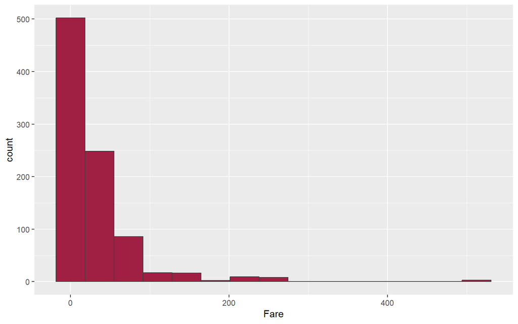

```r
# create histogram for Fare
training_data %>%
  ggplot(aes(x = Fare)) +
  geom_histogram(bins = 15, fill = "#9F2042", color = "#404040")
```

#### `Cabin`

```r
# Get count of Cabin number
training_data %>%
  count(Cabin) %>%
  datatable(rownames = FALSE,
            options = list(dom = "tp"))
```

| Cabin | n |
| --- | --- |
| A10 | 1 |
| A14 | 1 |
| A16 | 1 |
| A19 | 1 |
| A20 | 1 |
| A23 | 1 |
| A24 | 1 |
| A26 | 1 |
| A31 | 1 |
| A32 | 1 |

[output cut: 138 more lines]

These can be cleaned up to show `Cabin` by section.

```r
training_data %>%
  mutate(Cabin_letter = str_sub(Cabin, start = 1, end = 1)) %>%
  count(Cabin_letter) %>%
  datatable(rownames = FALSE,
            options = list(dom = "tp"))
```

| Cabin_letter | n |
| --- | --- |
| A | 15 |
| B | 47 |
| C | 59 |
| D | 33 |
| E | 32 |
| F | 13 |
| G | 4 |
| T | 1 |
|  | 687 |

Perhaps we can predict the `Cabin` letter using the fare price or class.

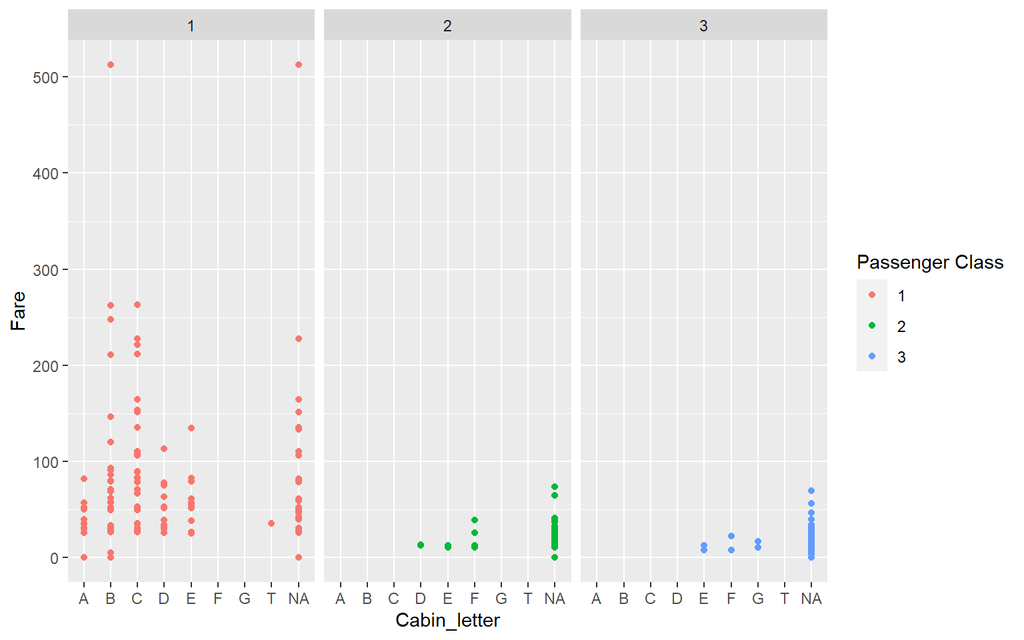

```r
training_data %>%
  mutate(Cabin_letter = str_sub(Cabin, start = 1, end = 1)) %>%
  ggplot(aes(y = Fare, x = Cabin_letter, color = as.factor(Pclass))) +
  geom_point() +
  facet_grid(~Pclass) +
  labs(color = "Passenger Class")
```

#### `Embarked`

```r
# get count of point of embarkment
training_data %>%
  count(Embarked) %>%
  datatable(rownames = FALSE,
            options = list(dom = "tp"))
```

| Embarked | n |
| --- | --- |
| C | 168 |
| Q | 77 |
| S | 644 |
|  | 2 |

## Missingness

There were 529 passengers missing data only about their `Cabin`. There were 19 passengers missing data only about their `age`. There were 2 passengers missing data only about their `embarkment`. There were 158 passsengers missing data for both their `Cabin` and their `age’.

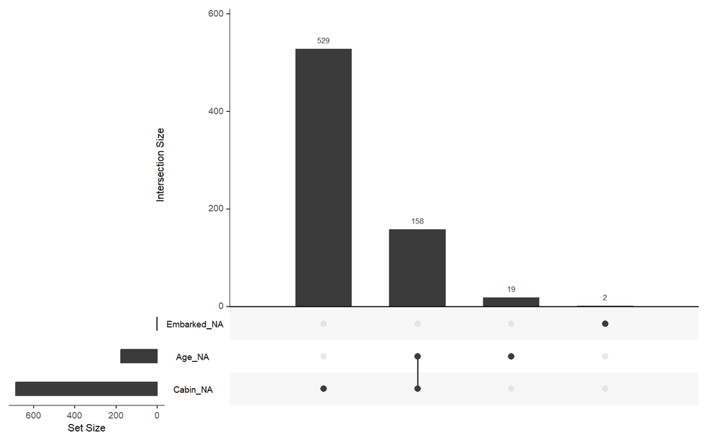

```r
naniar::gg_miss_upset(training_data, nsets = 3)
```

## Prep Data for Model

```r
# remove unneeded character data and IDs
# remove rows with missing data (for now)
training_data_complete <- training_data %>%
  select(-Name,-PassengerId,-Ticket,-Cabin,-Embarked) %>%
  drop_na()

dataset <- recipe(Survived ~ ., training_data_complete) %>%
  step_dummy(Sex, one_hot = TRUE) %>%
  step_scale()

prep(dataset,
     verbose=TRUE)
```

```
## oper 1 step dummy [training]
## oper 2 step scale [training]
## The retained training set is ~ 0.05 Mb  in memory.
```

```
## -- Recipe ----------------------------------------------------------------------
```

```
## -- Inputs
```

```
## Number of variables by role
```

```
## outcome:   1
## predictor: 6
```

```
## -- Training information
```

```
## Training data contained 714 data points and no incomplete rows.
```

```
## -- Operations
```

```
## * Dummy variables from: Sex | Trained
```

```
## * Scaling for: <none> | Trained
```

```r
dataset <- dataset %>%
  prep() %>%
  bake(new_data = NULL)
```

```r
# create initial partition of train/test data using the imported training data from Kaggle
split <- initial_split(dataset, 0.8)
train_dataset <- training(split)
test_dataset <- testing(split)
```

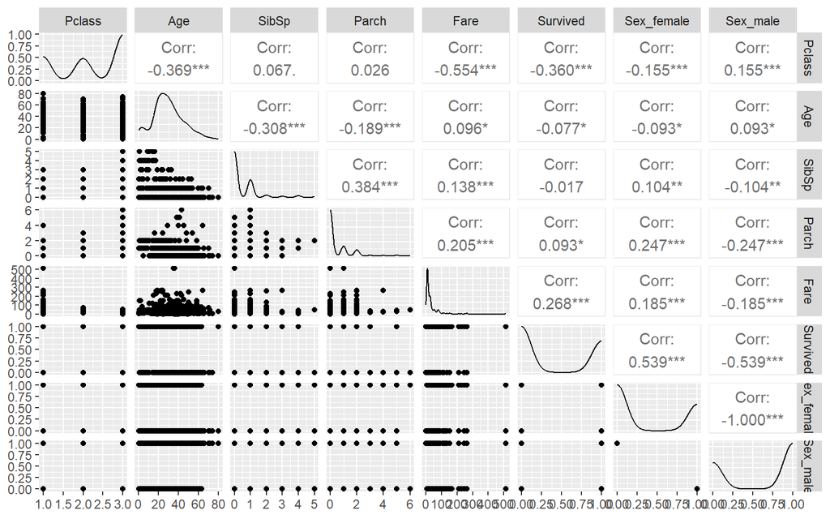

```r
dataset %>%
  GGally::ggpairs()
```

```r
train_features <- train_dataset %>% select(-Survived)
test_features <- test_dataset %>% select(-Survived)

train_labels <- train_dataset %>% select(Survived)
test_labels <- test_dataset %>% select(Survived)
```

```r
normalizer <- layer_normalization(axis = -1L)

normalizer %>% adapt(as.matrix(train_features))
```

```r
linear_model <- keras_model_sequential() %>%
  normalizer() %>%
  layer_dense(64, activation = 'relu') %>%
  layer_dense(64, activation = 'relu') %>%
  layer_dense(units = 1)

predict(linear_model, as.matrix(train_features[1:10, ]))
```

```
##              [,1]
##  [1,]  0.01308466
##  [2,] -0.18253516
##  [3,] -0.23686221
##  [4,] -0.17576879
##  [5,] -0.18602791
##  [6,] -0.24815553
##  [7,] -0.02336620
##  [8,] -0.13995391
##  [9,] -0.21481086
## [10,] -0.03449254
```

```r
linear_model %>% compile(
  optimizer = optimizer_adam(learning_rate = 0.05,),
  loss = loss_binary_crossentropy(from_logits = TRUE),
  metrics = list(metric_binary_accuracy(threshold = 0))
)

history <- linear_model %>% fit(
  as.matrix(train_features),
  as.matrix(train_labels),
  epochs = 100,
  # Suppress logging.
  verbose = 1,
  # Calculate validation results on 20% of the training data.
  validation_split = 0.2
)

results <- linear_model %>%
  evaluate(
    as.matrix(test_features),
    as.matrix(test_labels),
    verbose = 0
  )

results
```

```
##            loss binary_accuracy
##       0.5983096       0.7832168
```

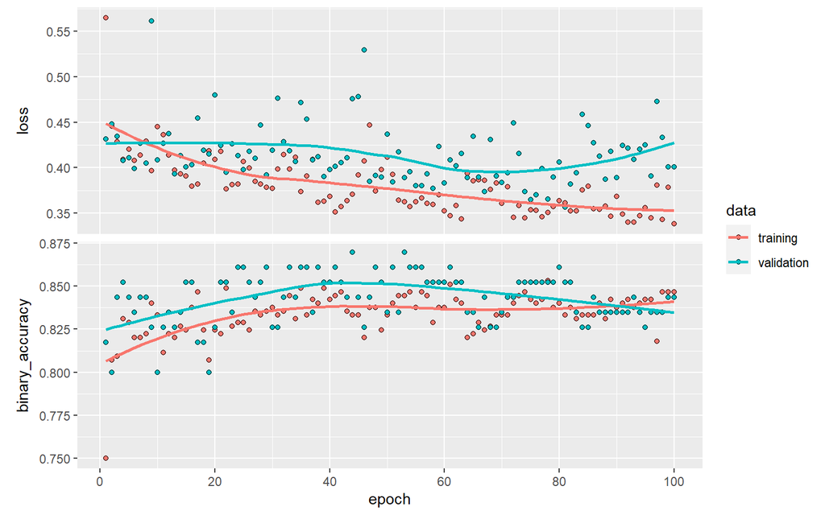

```r
plot(history)
```